# Лабораторная работа №6

Решение моделей в непрерывном и дискретном времени

Умед Джамшедович Назармамадов

Российский университет дружбы народов

2026-11-22

# Информация

## Докладчик

- Назармамадов Умед Джамшедович
- Студент группы НФИбд-02-23
- Факультет физико-математических и естественных наук
- Российский университет дружбы народов

# Вводная часть

## Актуальность

- Динамические модели описывают изменение системы во времени
- Непрерывные модели задают скорость изменения состояния
- Дискретные модели задают переход от одного шага к следующему
- Графики и фазовые портреты помогают увидеть рост, колебания и приближение к равновесию

## Объект и предмет исследования

- **Объект исследования** включает непрерывные и дискретные динамические модели
- **Предмет исследования** охватывает численные решения, фазовые траектории и равновесия

## Цель и задачи

**Цель работы** состоит в освоении пакетов Julia для решения задач в непрерывном и дискретном времени.

- Повторить три примера из методических указаний
- Выполнить восемь самостоятельных заданий
- Построить графики, фазовые портреты и анимации
- Сравнить решения и проверить результаты вычислений

## Материалы и методы

- Julia и JupyterLab с ядром IJulia
- `DifferentialEquations` и метод `Tsit5()` для решения ОДУ
- Прямые итерации и линеаризация для дискретной модели
- `Plots` с бэкендом PyPlot для графиков и GIF-анимаций

# Ход работы

## Экспоненциальный рост

- Задача $u'=0{,}98u$ с начальным условием $u(0)=1$
- Точное решение $u(t)=e^{0{,}98t}$
- При строгих допусках максимальная ошибка уменьшилась примерно в 619 раз

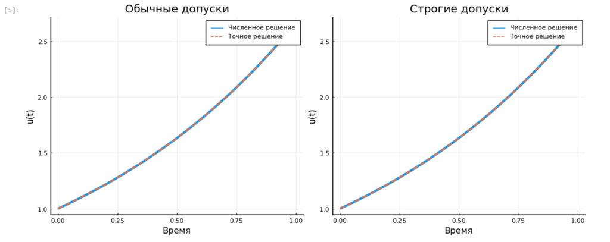

Численное и точное решения при разных допусках

## Система Лоренца

- Слева траектория по точкам, сохранённым решателем
- Справа та же траектория на равномерной сетке из 6000 точек

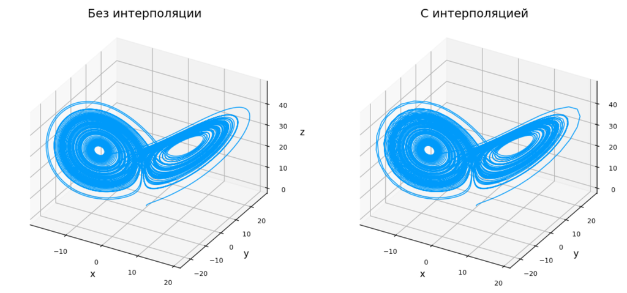

Фазовые портреты системы Лоренца

## Непрерывная модель Лотки–Вольтерры

- Численности жертв и хищников колеблются
- Пики численности хищников наступают позже пиков численности жертв

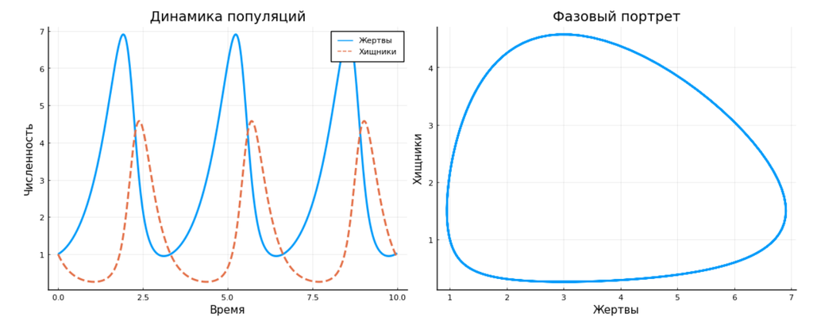

Динамика популяций и замкнутая фазовая траектория

## Модели Мальтуса и логистического роста

- В обеих моделях $x(0)=10$ и коэффициент роста равен $0{,}2$
- При $t=20$ модель Мальтуса даёт $545{,}98$, логистическая модель даёт $85{,}85$

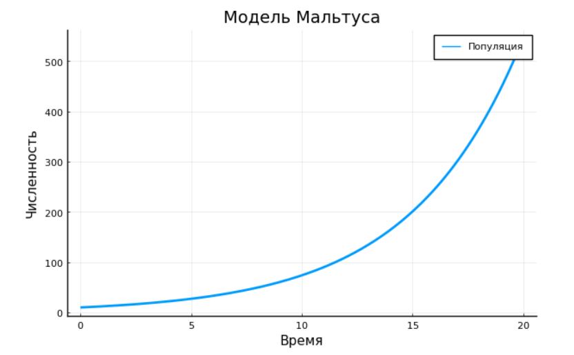

Модель Мальтуса

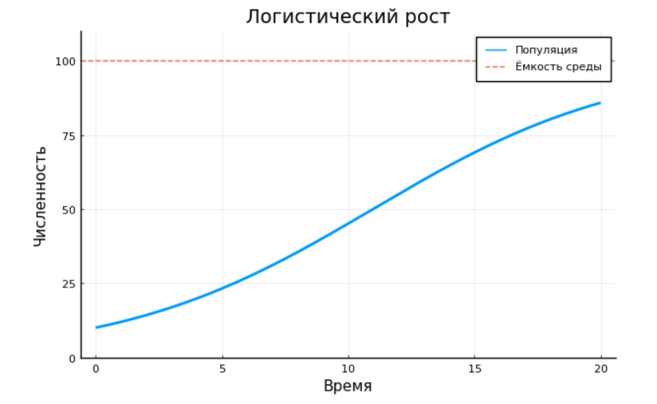

Логистическая модель

## Модели SIR и SEIR

- В SIR три группы: восприимчивые $S$, заразные $I$ и выбывшие $R$
- В SEIR добавлена скрытая стадия $E$
- Сумма долей в обеих моделях сохраняется

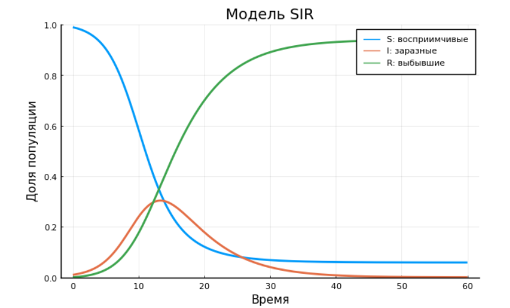

Модель SIR

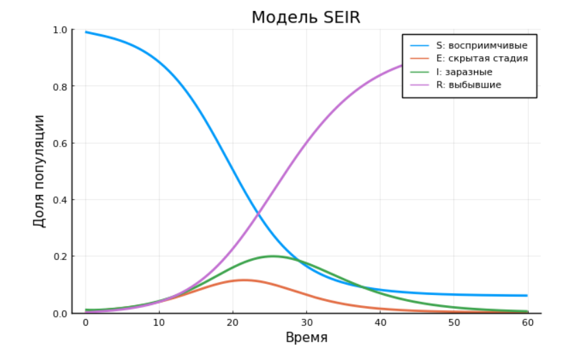

Модель SEIR

## Сравнение пиков SIR и SEIR

| Модель | Пиковая доля заразных | Время пика |
| --- | --- | --- |
| SIR | 30,38 % | 13,4 |
| SEIR | 19,86 % | 25,4 |

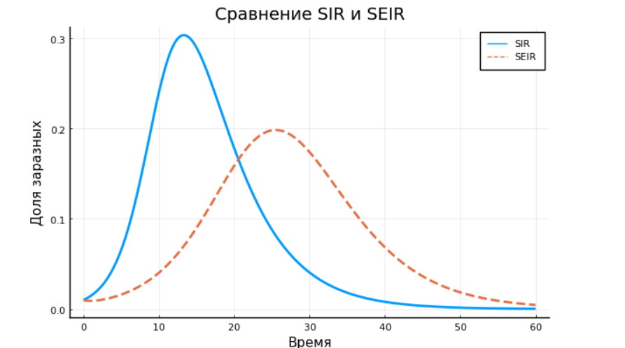

Доля заразных в двух моделях

## Дискретная модель Лотки–Вольтерры

- Точка сосуществования $(0{,}4;\,0{,}2)$
- Выполнено 30 итераций из начальной точки $(0{,}41;\,0{,}19)$
- Прямые итерации и линейное приближение сходятся к равновесию по спирали

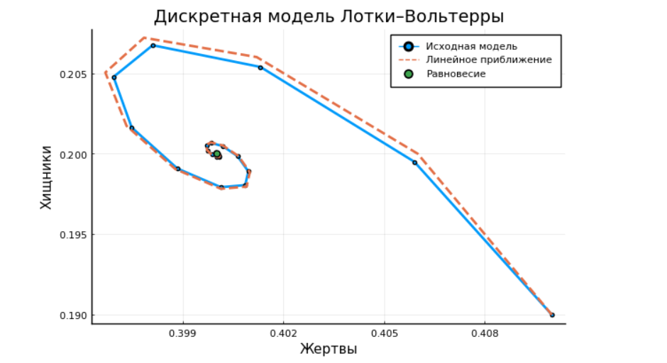

Фазовые траектории дискретной модели

## Конкуренция популяций

- Начальные численности равны 12 и 8
- При одинаковом коэффициенте роста первая популяция растёт, вторая сокращается
- Разность численностей равна $4e^{0{,}4t}$

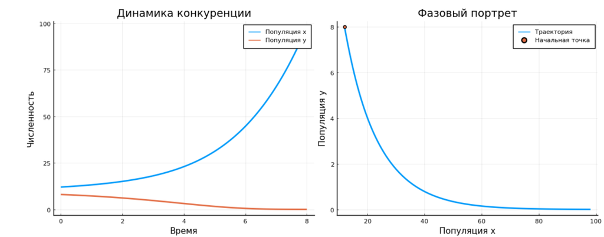

Динамика конкурентных популяций и фазовый портрет

## Осциллятор без затухания

- Начальное смещение $x(0)=1$, начальная скорость $v(0)=0$
- Амплитуда постоянна, фазовая траектория имеет форму окружности
- Энергия численного решения остаётся близкой к $0{,}5$

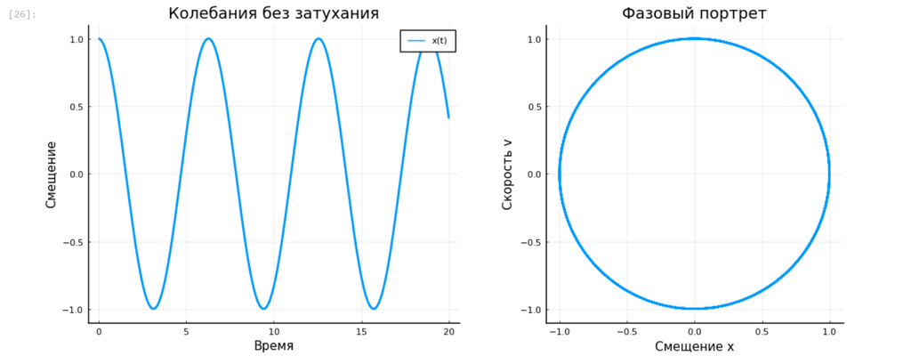

Гармонические колебания без затухания

## Осциллятор с затуханием

- Те же начальные условия и коэффициент затухания $\gamma=0{,}2$
- Амплитуда уменьшается, фазовая траектория сходится к началу координат
- Энергия снизилась с $0{,}5$ до примерно $0{,}0002083$ при $t=20$

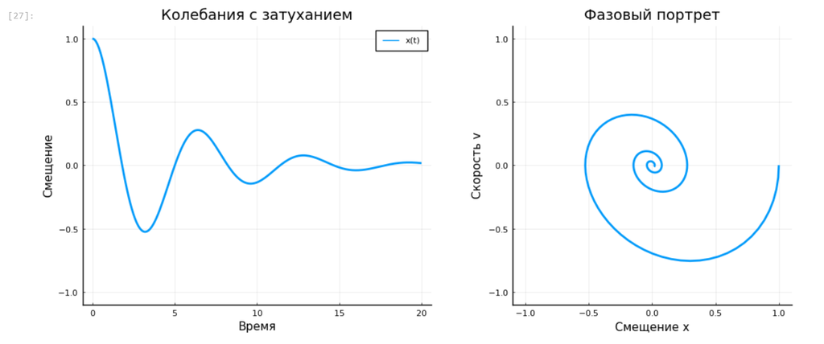

Затухающие колебания и фазовая спираль

# Результаты

## Что получено

- Воспроизведены три примера и выполнены восемь самостоятельных заданий
- Построены графики и фазовые портреты, сохранены шесть GIF-анимаций
- Оценена ошибка относительно точного решения для экспоненциального роста
- Проверены равновесия дискретной модели, суммы долей в SIR и SEIR и энергия осцилляторов

# Заключение

## Главный вывод

Численное решение в Julia позволяет проследить изменение состояния системы во времени. Графики показывают рост и колебания, а фазовые портреты помогают увидеть периодическое движение и приближение к равновесию.